# Ejercicio 5

## David Montero Loaiza

### Problema 1

Crea una función a la que se le pase como input: la media en el eje x, la media en el eje y, la varianza en el eje x, la varianza en el eje y y la covarianza de x e y, junto con un número de puntos N, y devuelva una matriz con N filas y 2 columnas con los números que salen de la distribución gaussiana de dos dimensiones definidas por los valores de input (usar la función MASS::mvrnorm)

```r
# PAQUETE REQUERIDO
require(MASS)
generate_matrix = function(N,meanX,meanY,varX,varY,covXY){

  # MATRIZ DE COVARIANZA
  Sigma = matrix(c(meanX,covXY,covXY,meanY),byrow = TRUE,ncol = 2)

  # MEDIAS
  mu = c(meanX,meanY)

  # MATRIZ DE DOS DIMENSIONES CON DISTRIBUCIONES GAUSSIANAS SEGUN PARAMETROS
  mat = mvrnorm(N,mu,Sigma)

  return(mat)

}
```

### Problema 2

Genera una matrix x1 usando la función anterior y tomando: N = 1000, mu_x = 2, mu_y = 4, var_x = var_y = 1, y Cov(x,y) = 0.3. Crea una matriz “y1” con tantas filas como la matriz x y asígnale el valor 0.

```r
# PARAMETROS PARA UNA MATRIZ CUYO VALOR DE Y CORRESPONDE A 0
N = 1000
mu_x = 2
mu_y = 4
var_x = 1
var_y = var_x
covXY = 0.3

x1 = generate_matrix(N,mu_x,mu_y,var_x,var_y,covXY)

# VALOR DE Y PARA LA MATRIZ
y1 = rep(0,nrow(x1))
```

### Problema 3

Repite 2) para otra muestra con N = 1000, mu_x = 6, mu_y = 3, var_x = var_y = 1, y Cov(x,y) = 0.3. Crea una matriz “y2” con tantas filas como la matriz x2 y asígnale el valor 1.

```r
# PARAMETROS PARA UNA MATRIZ CUYO VALOR DE Y CORRESPONDE A 0
N = 1000
mu_x = 6
mu_y = 3
var_x = 1
var_y = var_x
covXY = 0.3

x2 = generate_matrix(N,mu_x,mu_y,var_x,var_y,covXY)

# VALOR DE Y PARA LA MATRIZ
y2 = rep(1,nrow(x2))
```

### Problema 4

Junta las matrices x1, x2, y y1, y2 en una sola matriz x y una sola matriz y.

```r
# MATRIZ X
x = rbind(x1,x2)

# VECTOR Y
y = c(y1,y2)
```

### Problema 5

Usando las funciones de coste y gradiente del ejercicio 5, utiliza optim para un modelo en el que z = alpha_0 + alpha_1 x1 + alpha_2 x2, tomando como vector de parámetros inicial el (0, 0, 0). Calcula y pinta la frontera entre ambas distribuciones.

En el siguiente código se definen las funciones a utilizar.

```r
sigmoid = function(Z){

  # RETORNAR VALOR DE SIGMOIDE
  return(1/(1 + exp(-Z)) )

}

loss = function(alpha,x,y){

  # TAMANO DE X
  N = nrow(x)

  # CREAR MATRIZ X
  X = cbind(rep(1,N),x)

  # CALCULAR SIGMOIDE
  s = sigmoid(alpha %*% t(X))

  # CALCULAR VALOR DE LOSS
  loss = -sum(y * log(s) + (1 - y) * log(1 - s))/N

  # RETORNAR LOSS
  return(loss)

}

gradient = function(alpha,x,y){

  # TAMANO DE X (FILAS)
  N = nrow(x)

  # CREAR MATRIZ X
  X = cbind(rep(1,N),x)

  # SIGMOIDE
  s = sigmoid(alpha %*% t(X))

  # DIMENSIONES DE LA MATRIZ X + 1
  g = 1:length(alpha)

  # FUNCION PARA CALCULAR EL GRADIENTE SEGUN LAS DIMENSIONES DE LA MATRIZ + 1
  f = function(i) -sum((s - y) * -(X[,i]))/N

  # CALCULAR EL GRADIENTE SEGUN LAS DIMENSIONES DE LA MATRIZ
  grad = sapply(g,f)

  # RETORNAR VECTOR GRADIENTE
  return(grad)

}
```

A continuación se definen los parámetros iniciales para alpha y se calculan sus valores óptimos, graficando finalmente la división de las clases.

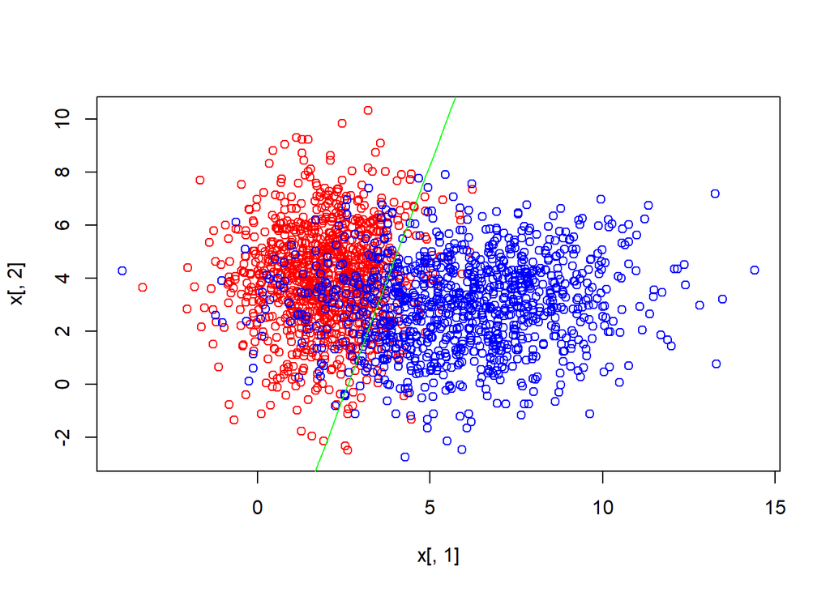

```r
# PARAMETROS INICIALES
init = c(0,0,0)

# OPTIMIZACION DE LOS PARAMETROS
op = optim(par = init, x = x, y = y, fn = loss, gr = gradient, method = "BFGS")

# ALPHA OPTIMO
alpha = op$par

# GRAFICA DE LA DIVISION OPTIMA DE CLASES
plot(x[,1],x[,2],col = c("red","blue")[as.factor(y)])
curve((-alpha[1]/alpha[3]) - (alpha[2]*x/alpha[3]),add = TRUE, col = "green")
```

### Problema 6

Repite otra vez 1, 2, 3 y 4 para obtener otras matrices x e y independientes. Utilizando la “sigma” calculada anteriormente calcula el TPR, TNR, FPR y FNR para valores del threshold = 0.3, 0.5, 0.7.

A continuación se definen nuevas matrices x e y independientes.

```r
# PARAMETROS PARA UNA MATRIZ CUYO VALOR DE Y CORRESPONDE A 0
N = 1000
mu_x = 2
mu_y = 4
var_x = 1
var_y = var_x
covXY = 0.3

x1 = generate_matrix(N,mu_x,mu_y,var_x,var_y,covXY)
y1 = rep(0,nrow(x1))

# PARAMETROS PARA UNA MATRIZ CUYO VALOR DE Y CORRESPONDE A 1
N = 1000
mu_x = 6
mu_y = 3
var_x = 1
var_y = var_x
covXY = 0.3

x2 = generate_matrix(N,mu_x,mu_y,var_x,var_y,covXY)
y2 = rep(1,nrow(x2))

# NUEVA MATRIZ X
x = rbind(x1,x2)

# NUEVO VECTOR Y
y = c(y1,y2)
```

Aquí se definen nuevas funciones para calcular la matriz de confusión y extraer los errores asociados. También se define una función para realizar una predicción usando la sigmoide con un umbral que puede variar.

```r
confusion_matrix = function(y,y_pred){

  # MATRIZ DE CONFUSION
  cM = table(as.data.frame(cbind(y_pred,y)))

  # PARAMETROS DE LA MATRIZ
  TP = cM[1,1]
  FP = cM[1,2]
  FN = cM[2,1]
  TN = cM[2,2]

  # VARIABLES PARA MEDIR EL ERROR
  TPR = TP/(TP + FN)
  TNR = TN/(FP + TN)
  FPR = FP/(FP + TN)
  FNR = FN/(TP + FN)

  # ERRORES EN UN DATAFRAME
  df = data.frame(TP,FP,FN,TN,TPR,TNR,FPR,FNR)

  # SE ENLISTAN VARIABLES A RETORNAR
  l = list("confusion_matrix" = cM,"errors" = df)

  # SE RETORNA LA LISTA
  return(l)

}

predict_sigmoid = function(alpha,x,y,threshold){

  # TAMANO DE X (FILAS)
  N = nrow(x)

  # CREAR MATRIZ X
  X = cbind(rep(1,N),x)

  # SIGMOIDE
  s = as.vector(sigmoid(alpha %*% t(X)))

  # APLICAR UMBRAL
  s[s >= threshold] = 1
  s[s != 1] = 0

  # RETORNAR VALORES PREDICHOS
  return(s)

}
```

Ahora se evalúan diferentes valores para el umbral.

```r
# UMBRALES A EVALUAR
thresholds = c(0.3,0.5,0.7)

# VARIABLE PARA ALMACENAR EL DATA FRAME DE ERRORES
err = NULL

for(th in thresholds){

  # PREDICCION
  y_pred = predict_sigmoid(alpha,x,y,th)

  # MATRIZ DE CONFUSION
  cm = confusion_matrix(y,y_pred)

  # DATAFRAME CON ERRORES
  err = rbind(err,cm$errors)

}

# SE AGREGAN LOS UMBRALES AL DATAFRAME
err = cbind(thresholds,err)

err
```

| thresholds | TP | FP | FN | TN | TPR | TNR | FPR | FNR |
| --- | --- | --- | --- | --- | --- | --- | --- | --- |
| 0.3 | 733 | 94 | 267 | 906 | 0.733 | 0.906 | 0.094 | 0.267 |
| 0.5 | 856 | 153 | 144 | 847 | 0.856 | 0.847 | 0.153 | 0.144 |
| 0.7 | 943 | 235 | 57 | 765 | 0.943 | 0.765 | 0.235 | 0.057 |